# Module Seven Activity

For the module seven activity, you will identify relevant data and write Python code to generate visualizations and interpret insights from the provided data set. Professionals in data-driven fields must not only interpret data but also gather, analyze, and present it in meaningful and actionable ways. This activity allows you to practice these essential skills by working through the complete exploratory data analysis (EDA) process.

*Note:* there are two parts to this assignment. Part One is the coding activity. Part Two is the written report.

Once your code is complete, you will download this notebook as an HTML file by clicking **File**, then **Download As**, then **HTML (.html)** from the Jupyter menu bar. Validate that your code, output, and all visualizations (rendered as images using the display() function) are visible in the html file before submission.

*Missing Blocks:* Ensure that you have clicked **Run** for all blocks before downloading as an HTML file or the block may be missing from your submission. **Images** must be called using the *display()* function, for example: **display(Image(filename="output/{image_name}.png"))**

Specifically, you must address the items from the rubric criteria.

### Part One: Python Code

In this part, you will write Python code to analyze the data and generate visualizations that explore trends.

#### Create multiple, distinct visualizations that explore different aspects of the data using Python Libraries.

Include the following:

- Code comments explaining each step of your analysis

### Part Two: Report

In this part, you will write a reflection to explain the insights gained from your analysis and visualizations. *This part is to be completed in a word document, using the output here to answer the topics.*

- Explain the trends, differences, or outliers you observed in the data.
- Describe any disparities or patterns that may be relevant to the nonprofit’s goals.
- Write a summary of what the data suggests about transit usage across neighborhoods.
- Explain how the visualizations support your conclusions.
- Discuss how your findings could inform the nonprofit’s decision-making or strategy.
- Describe the importance of data-driven insights in addressing real-world challenges.

*To Begin:* This Python template program has been broken down into segments as a guide for what steps you should do at a minimum to complete this activity. Look for the **# To Do:** comments. These are placeholders for you to provide Python code segments. Fill out all **# To Do:** code segments to complete this program.  
*Once Complete:* Execute a "Kernel restart and run all" to verify that all your code works as a single unit by clicking **Kernel**, then **Restart & Run All** before downloading as html.

*Hint:* If you need to install additional packages, see one of the earlier modules on how to configure and call a requirements.txt file.

## Import the Required Packages

```python
import pandas as pd
import matplotlib.pyplot as plt
import seaborn as sns
import os
import matplotlib.image as mpimg

from pathlib import Path  # ensures Path is available even if cells are run out of order
from IPython.display import Image, display  # for image rendering in html output
```

# Part One: Python Code

*Reminder:* Ensure that you add code comments explaining each step of your analysis.

## Define the file path for the dataset

```python
data_path = "data/Feb_2025_Complete_Monthly_Ridership.csv"
```

## Loading the dataset

```python
# To Do: Load the dataset

# In Codio, the dataset file name/location can vary depending on the lab setup.
# To avoid path headaches, I check a few common filenames first, then fall back
# to auto-detecting a likely CSV in the workspace.

possible_paths = [
    Path("transit_usage.csv"),
    Path("transit.csv"),
    Path("ridership.csv"),
    Path("data/transit_usage.csv"),
    Path("data/transit.csv"),
    Path("data/ridership.csv"),
    Path("dataset.csv"),
    Path("data/dataset.csv"),
    Path(data_path),  # include the provided default path as an option too
]

# First pass: pick the first path that exists.
data_path = next((p for p in possible_paths if p.exists()), None)

# If none of the common names match, try to locate a CSV automatically.
if data_path is None:
    csv_candidates = [
        p for p in Path(".").rglob("*.csv")
        if "output" not in p.parts and ".ipynb_checkpoints" not in p.parts
    ]

    # If there's only one CSV, that's almost always the dataset we need.
    if len(csv_candidates) == 1:
        data_path = csv_candidates[0]
    else:
        # If there are multiple CSVs, pick the one that looks most “transit-ish”.
        keywords = ("transit", "ridership", "usage", "neighborhood")
        ranked = sorted(
            csv_candidates,
            key=lambda p: sum(k in p.name.lower() for k in keywords),
            reverse=True,
        )
        data_path = ranked[0] if ranked else None

# If we still didn't find a file, stop here with a clear message.
if data_path is None:
    raise FileNotFoundError(
        "Could not find the dataset CSV automatically. "
        "Update 'possible_paths' with the correct filename/path and re-run this cell."
    )

# Load the dataset into a DataFrame (df) so we can start exploring it.
df = pd.read_csv(data_path)

# Quick confirmation prints help catch issues early (wrong file, empty data, etc.).
print(f"Loaded dataset from: {data_path}")
print(f"Rows: {len(df):,} | Columns: {df.shape[1]:,}")

# Display a preview so we can confirm the columns and values look right.
df.head()
```

```
Loaded dataset from: data/Feb_2025_Complete_Monthly_Ridership.csv
Rows: 2,311 | Columns: 27
```

|  | NTD ID | Legacy NTD ID | Agency | Mode | TOS | 3 Mode | Mode/Type of Service Status | Reporter Type | Organization Type | HQ City | ... | Last Closed Report Year | Last Closed FY End Month | Last Closed FY End Year | Passenger Miles FY | Unlinked Passenger Trips FY | Avg Trip Length FY | Fares FY | Operating Expenses FY | Avg Cost Per Trip FY | Avg Fares Per Trip FY |
| --- | --- | --- | --- | --- | --- | --- | --- | --- | --- | --- | --- | --- | --- | --- | --- | --- | --- | --- | --- | --- | --- |
| 0 | 1 | 0001 | King County | DR | PT | Bus | Active | Full Reporter | City, County or Local Government Unit or Depar... | SEATTLE | ... | 2023.0 | 12.0 | 2023.0 | 6,470,644 | 888,663 | 7.0 | $816,892.00 | $72,095,003.00 | $81.13 | $0.92 |
| 1 | 1 | 0001 | King County | DR | TX | Bus | Active | Full Reporter | City, County or Local Government Unit or Depar... | SEATTLE | ... | 2023.0 | 12.0 | 2023.0 | 1,509,526 | 121,496 | 12.0 | $105,605.00 | $5,658,724.00 | $46.58 | $0.87 |
| 2 | 1 | 0001 | King County | FB | DO | Ferry | Active | Full Reporter | City, County or Local Government Unit or Depar... | SEATTLE | ... | 2023.0 | 12.0 | 2023.0 | 1,479,694 | 399,687 | 4.0 | $1,493,280.00 | $8,625,721.00 | $21.58 | $3.74 |
| 3 | 1 | 0001 | King County | LR | DO | Rail | Inactive | Full Reporter | City, County or Local Government Unit or Depar... | SEATTLE | ... | 2011.0 | 12.0 | 2011.0 | 471,587 | 520,933 | 1.0 | $288,470.00 | $2,281,393.00 | $4.38 | $0.55 |
| 4 | 1 | 0001 | King County | MB | DO | Bus | Active | Full Reporter | City, County or Local Government Unit or Depar... | SEATTLE | ... | 2023.0 | 12.0 | 2023.0 | 244,710,079 | 63,485,248 | 4.0 | $60,386,305.00 | $710,359,423.00 | $11.19 | $0.95 |

5 rows × 27 columns

## Create an output folder if it doesn't already exist

```python
output_folder = "output"

# Create an output folder so saved charts (PNG files) have a consistent place to go.
# This also helps when exporting to HTML, because we can display the saved images from this folder.
os.makedirs(output_folder, exist_ok=True)
```

## Display Dataset Information

```python
# Display Dataset Information
print("Dataset Overview:")

# To Do: Print the first 5 rows of the dataset to inspect the data to ensure it loaded correctly

# Quick sanity checks so I know the file loaded and looks like the right dataset.
print(f"Shape (rows, columns): {df.shape}")
print("\nColumns:")
print(df.columns.tolist())

# df.info() is a quick EDA snapshot: data types + non-null counts per column.
# This helps me spot missing values and columns that need cleaning (like numbers stored as text).
print("\nData types and non-null counts:")
df.info()

# First 5 rows: this is the fastest way to confirm the data loaded correctly
# and to see what the column names and values look like before cleaning.
df.head()
```

```
Dataset Overview:
Shape (rows, columns): (2311, 27)

Columns:
['NTD ID', 'Legacy NTD ID', 'Agency', 'Mode', 'TOS', '3 Mode', 'Mode/Type of Service Status', 'Reporter Type', 'Organization Type', 'HQ City', 'HQ State', 'UACE CD', 'UZA Name', 'UZA SQ Miles', 'UZA Population', 'Service Area Population', 'Service Area SQ Miles', 'Last Closed Report Year', 'Last Clo…

Data types and non-null counts:
<class 'pandas.core.frame.DataFrame'>
RangeIndex: 2311 entries, 0 to 2310
Data columns (total 27 columns):
 #   Column                       Non-Null Count  Dtype
---  ------                       --------------  -----
 0   NTD ID                       2311 non-null   int64
 1   Legacy NTD ID                2224 non-null   object
 2   Agency                       2311 non-null   object
 3   Mode                         2311 non-null   object
 4   TOS                          2311 non-null   object
 5   3 Mode                       2311 non-null   object
 6   Mode/Type of Service Status  2311 non-null   object
 7   Reporter Type                2311 non-null   object
 8   Organization Type            2311 non-null   object
 9   HQ City                      2311 non-null   object
 10  HQ State                     2311 non-null   object
 11  UACE CD                      2305 non-null   float64
 12  UZA Name                     2305 non-null   object
 13  UZA SQ Miles                 2305 non-null   float64
 14  UZA Population               2305 non-null   float64
 15  Service Area Population      2263 non-null   float64
 16  Service Area SQ Miles        2263 non-null   float64
 17  Last Closed Report Year      2284 non-null   float64
 18  Last Closed FY End Month     2284 non-null   float64
 19  Last Closed FY End Year      2284 non-null   float64
 20  Passenger Miles FY           1900 non-null   object
 21  Unlinked Passenger Trips FY  1900 non-null   object
 22  Avg Trip Length FY           1900 non-null   float64
 23  Fares FY                     1905 non-null   object
 24  Operating Expenses FY        1920 non-null   object
 25  Avg Cost Per Trip FY         1900 non-null   object
 26  Avg Fares Per Trip FY        1900 non-null   object
dtypes: float64(9), int64(1), object(17)
memory usage: 487.6+ KB
```

|  | NTD ID | Legacy NTD ID | Agency | Mode | TOS | 3 Mode | Mode/Type of Service Status | Reporter Type | Organization Type | HQ City | ... | Last Closed Report Year | Last Closed FY End Month | Last Closed FY End Year | Passenger Miles FY | Unlinked Passenger Trips FY | Avg Trip Length FY | Fares FY | Operating Expenses FY | Avg Cost Per Trip FY | Avg Fares Per Trip FY |
| --- | --- | --- | --- | --- | --- | --- | --- | --- | --- | --- | --- | --- | --- | --- | --- | --- | --- | --- | --- | --- | --- |
| 0 | 1 | 0001 | King County | DR | PT | Bus | Active | Full Reporter | City, County or Local Government Unit or Depar... | SEATTLE | ... | 2023.0 | 12.0 | 2023.0 | 6,470,644 | 888,663 | 7.0 | $816,892.00 | $72,095,003.00 | $81.13 | $0.92 |
| 1 | 1 | 0001 | King County | DR | TX | Bus | Active | Full Reporter | City, County or Local Government Unit or Depar... | SEATTLE | ... | 2023.0 | 12.0 | 2023.0 | 1,509,526 | 121,496 | 12.0 | $105,605.00 | $5,658,724.00 | $46.58 | $0.87 |
| 2 | 1 | 0001 | King County | FB | DO | Ferry | Active | Full Reporter | City, County or Local Government Unit or Depar... | SEATTLE | ... | 2023.0 | 12.0 | 2023.0 | 1,479,694 | 399,687 | 4.0 | $1,493,280.00 | $8,625,721.00 | $21.58 | $3.74 |
| 3 | 1 | 0001 | King County | LR | DO | Rail | Inactive | Full Reporter | City, County or Local Government Unit or Depar... | SEATTLE | ... | 2011.0 | 12.0 | 2011.0 | 471,587 | 520,933 | 1.0 | $288,470.00 | $2,281,393.00 | $4.38 | $0.55 |
| 4 | 1 | 0001 | King County | MB | DO | Bus | Active | Full Reporter | City, County or Local Government Unit or Depar... | SEATTLE | ... | 2023.0 | 12.0 | 2023.0 | 244,710,079 | 63,485,248 | 4.0 | $60,386,305.00 | $710,359,423.00 | $11.19 | $0.95 |

5 rows × 27 columns

```python
print("Column Names:")

# To Do: Print all column names

# Printing the full list helps me confirm the exact spelling/casing
# so I can reference the right columns in filtering and visualizations.
print(f"Total columns: {len(df.columns)}\n")

for i, col in enumerate(df.columns, start=1):
    print(f"{i:02d}. {col}")
```

```
Column Names:
Total columns: 27

01. NTD ID
02. Legacy NTD ID
03. Agency
04. Mode
05. TOS
06. 3 Mode
07. Mode/Type of Service Status
08. Reporter Type
09. Organization Type
10. HQ City
11. HQ State
12. UACE CD
13. UZA Name
14. UZA SQ Miles
15. UZA Population
16. Service Area Population
17. Service Area SQ Miles
18. Last Closed Report Year
19. Last Closed FY End Month
20. Last Closed FY End Year
21. Passenger Miles FY
22. Unlinked Passenger Trips FY
23. Avg Trip Length FY
24. Fares FY
25. Operating Expenses FY
26. Avg Cost Per Trip FY
27. Avg Fares Per Trip FY
```

```python
neighborhoods = ["King County", "City of Longview", "Spokane Transit Authority"]

# To Do: Filter the data for the three neighborhoods and create an explicit copy

# First, figure out which column actually contains the neighborhood/agency names.
# Different datasets name this differently, so I check common possibilities.
possible_neighborhood_cols = ["Neighborhood", "neighborhood", "Agency", "agency", "Region", "region", "Area", "area"]
neigh_col = next((c for c in possible_neighborhood_cols if c in df.columns), None)

# If none of the common names match, fall back to a simple guess:
# look for the first column name that contains "neigh", "agency", or "region".
if neigh_col is None:
    candidates = [c for c in df.columns if any(k in c.lower() for k in ["neigh", "agency", "region", "area"])]
    neigh_col = candidates[0] if candidates else None

if neigh_col is None:
    raise KeyError(
        "Could not identify the neighborhood/agency column. "
        "Please check df.columns and set 'neigh_col' manually."
    )

# Clean up the neighborhood/agency text so the filter is reliable.
# (This helps if there are extra spaces or inconsistent capitalization.)
df[neigh_col] = df[neigh_col].astype(str).str.strip()

# To make the filter more reliable, I compare a normalized (lowercase) version.
# This protects against small casing differences without changing the original values.
normalized_neighborhoods = [n.strip().lower() for n in neighborhoods]
df["_agency_match_key"] = df[neigh_col].str.lower()

# Filter down to the three neighborhoods/agencies and make an explicit copy (best practice).
filtered_df = df[df["_agency_match_key"].isin(normalized_neighborhoods)].copy()

# I don’t need the helper key after filtering, so I remove it to keep the dataset clean.
filtered_df.drop(columns=["_agency_match_key"], inplace=True, errors="ignore")

# Quick verification prints so I can confirm the filter worked.
print(f"Neighborhood column used: {neigh_col}")
print("Rows per neighborhood after filtering:")
print(filtered_df[neigh_col].value_counts(dropna=False))

filtered_df.head()
```

```
Neighborhood column used: Agency
Rows per neighborhood after filtering:
Agency
King County                  9
Spokane Transit Authority    4
City of Longview             4
Name: count, dtype: int64
```

|  | NTD ID | Legacy NTD ID | Agency | Mode | TOS | 3 Mode | Mode/Type of Service Status | Reporter Type | Organization Type | HQ City | ... | Last Closed Report Year | Last Closed FY End Month | Last Closed FY End Year | Passenger Miles FY | Unlinked Passenger Trips FY | Avg Trip Length FY | Fares FY | Operating Expenses FY | Avg Cost Per Trip FY | Avg Fares Per Trip FY |
| --- | --- | --- | --- | --- | --- | --- | --- | --- | --- | --- | --- | --- | --- | --- | --- | --- | --- | --- | --- | --- | --- |
| 0 | 1 | 0001 | King County | DR | PT | Bus | Active | Full Reporter | City, County or Local Government Unit or Depar... | SEATTLE | ... | 2023.0 | 12.0 | 2023.0 | 6,470,644 | 888,663 | 7.0 | $816,892.00 | $72,095,003.00 | $81.13 | $0.92 |
| 1 | 1 | 0001 | King County | DR | TX | Bus | Active | Full Reporter | City, County or Local Government Unit or Depar... | SEATTLE | ... | 2023.0 | 12.0 | 2023.0 | 1,509,526 | 121,496 | 12.0 | $105,605.00 | $5,658,724.00 | $46.58 | $0.87 |
| 2 | 1 | 0001 | King County | FB | DO | Ferry | Active | Full Reporter | City, County or Local Government Unit or Depar... | SEATTLE | ... | 2023.0 | 12.0 | 2023.0 | 1,479,694 | 399,687 | 4.0 | $1,493,280.00 | $8,625,721.00 | $21.58 | $3.74 |
| 3 | 1 | 0001 | King County | LR | DO | Rail | Inactive | Full Reporter | City, County or Local Government Unit or Depar... | SEATTLE | ... | 2011.0 | 12.0 | 2011.0 | 471,587 | 520,933 | 1.0 | $288,470.00 | $2,281,393.00 | $4.38 | $0.55 |
| 4 | 1 | 0001 | King County | MB | DO | Bus | Active | Full Reporter | City, County or Local Government Unit or Depar... | SEATTLE | ... | 2023.0 | 12.0 | 2023.0 | 244,710,079 | 63,485,248 | 4.0 | $60,386,305.00 | $710,359,423.00 | $11.19 | $0.95 |

5 rows × 27 columns

```python
# To Do: Convert numeric columns to proper formats (removing commas and extra spaces)

# Some datasets store numbers as text (ex: "12,345" or "  98,765 ").
# This loop looks for columns that are likely numeric and converts them safely.

# Identify object (string) columns that look like they contain numbers.
candidate_cols = []
for col in filtered_df.columns:
    if filtered_df[col].dtype == "object":
        # Grab a small sample of non-null values to test conversion.
        sample = filtered_df[col].dropna().astype(str).head(25)

        # If most sampled values can be converted after cleaning, treat it as numeric.
        # NOTE: This dataset includes currency-like values (ex: "$72,095,003.00"), so I strip "$" too.
        cleaned = (
            sample.str.replace(",", "", regex=False)
                  .str.replace("$", "", regex=False)
                  .str.strip()
        )
        convertible_ratio = pd.to_numeric(cleaned, errors="coerce").notna().mean() if len(cleaned) > 0 else 0

        if convertible_ratio >= 0.8:  # 80%+ convertible is a good signal
            candidate_cols.append(col)

# Convert the detected numeric-like text columns
converted_cols = []
for col in candidate_cols:
    filtered_df[col] = (
        filtered_df[col]
        .astype(str)
        .str.replace(",", "", regex=False)
        .str.replace("$", "", regex=False)
        .str.strip()
    )
    filtered_df[col] = pd.to_numeric(filtered_df[col], errors="coerce")
    converted_cols.append(col)

print("Converted numeric-like columns:")
print(converted_cols if converted_cols else "None detected")
```

```
Converted numeric-like columns:
['Legacy NTD ID', 'Passenger Miles FY', 'Unlinked Passenger Trips FY', 'Fares FY', 'Operating Expenses FY', 'Avg Cost Per Trip FY', 'Avg Fares Per Trip FY']
```

## Generate, Save, and Output Visualizations

*Example Visualizations:* The three visualization placeholders below are example visualization placeholders for the data using a provided template. These are simple example frameworks that you may use, but you may, and are encouraged to develop your own visualizations that you will then explain how the selected visualizations support your conclusions in the part two report.

In accordance with the scenario, three neighborhoods for evaluation are: King County, City of Longview, and Spokane Transit Authority which have been listed in the neighborhoods variable above.

### Visualization 1: Line chart of ridership trends over years

This is an example visualization you can generate. You may implement a chart and assessment of your choosing in lieu of this placeholder.

#### At a minimum include the following actions:

- Add title and axis labels
- Save the plot to a png file in the 'output' folder
- Use the display() function to render the generated png image in the html output
- Comments explaining each step of your analysis

```python
# To Do: Create a visualization that will support your conclusions for part two
# --- Step 1: Identify the ridership/usage column (numeric) ---
# I’m using keywords because different datasets label this differently.
ridership_keywords = ["ridership", "board", "boarding", "rides", "trips", "passenger", "usage", "count", "total"]
numeric_cols = filtered_df.select_dtypes(include="number").columns.tolist()

# Quick visibility helps explain what options existed if the auto-pick ever seems odd.
print(f"Numeric columns detected ({len(numeric_cols)}): {numeric_cols}")

ridership_col = None
for col in numeric_cols:
    if any(k in col.lower() for k in ridership_keywords):
        ridership_col = col
        break

# If nothing matched the keywords, use the “largest-scale” numeric column as a reasonable fallback.
# This is usually the ridership count column in transit datasets.
if ridership_col is None and numeric_cols:
    ridership_col = filtered_df[numeric_cols].max().sort_values(ascending=False).index[0]

if ridership_col is None:
    raise KeyError(
        "Could not identify a numeric ridership/usage column. "
        "Check numeric columns and set 'ridership_col' manually."
    )

print(f"Ridership/usage column used: {ridership_col}")
```

```
Numeric columns detected (17): ['NTD ID', 'Legacy NTD ID', 'UACE CD', 'UZA SQ Miles', 'UZA Population', 'Service Area Population', 'Service Area SQ Miles', 'Last Closed Report Year', 'Last Closed FY End Month', 'Last Closed FY End Year', 'Passenger Miles FY', 'Unlinked Passenger Trips FY', 'Avg Trip…
Ridership/usage column used: Passenger Miles FY
```

### Visualization 2: Bar chart comparing total ridership across neighborhoods

This is an example visualization you can generate. You may implement a chart and assessment of your choosing in lieu of this placeholder.

#### At a minimum include the following actions:

- Add title and axis labels
- Save the plot to a png file in the 'output' folder
- Use the display() function to render the generated png image in the html output
- Comments explaining each step of your analysis

```python
# To Do: Create a visualization that will support your conclusions for part two
# --- Step 2: Identify/create a date column for trends (if available) ---
# Best case: there's a single 'date' column we can parse.
date_candidates = [c for c in filtered_df.columns if "date" in c.lower()]
date_col = date_candidates[0] if date_candidates else None

# Common case: year + month exist separately (ex: Year=2022, Month=3)
year_candidates = [c for c in filtered_df.columns if c.lower() in ["year", "yr"]]
month_candidates = [c for c in filtered_df.columns if "month" in c.lower()]

# Build a working time column called 'trend_month'
filtered_df_plot = filtered_df.copy()

if date_col is not None:
    # Parse the date column safely (invalid parses become NaT)
    filtered_df_plot["trend_month"] = (
        pd.to_datetime(filtered_df_plot[date_col], errors="coerce")
        .dt.to_period("M")
        .dt.to_timestamp()
    )

elif year_candidates and month_candidates:
    ycol, mcol = year_candidates[0], month_candidates[0]
    # Convert to integers if needed, then create a consistent datetime for the first day of each month
    filtered_df_plot["trend_month"] = pd.to_datetime(
        dict(year=filtered_df_plot[ycol], month=filtered_df_plot[mcol], day=1),
        errors="coerce"
    )

else:
    # This dataset uses fiscal-year end fields instead of a normal "date" column.
    # If they exist, I can still build a usable time field for trend-style visuals.
    fy_year_col = "Last Closed FY End Year" if "Last Closed FY End Year" in filtered_df_plot.columns else None
    fy_month_col = "Last Closed FY End Month" if "Last Closed FY End Month" in filtered_df_plot.columns else None

    if fy_year_col and fy_month_col:
        filtered_df_plot["trend_month"] = pd.to_datetime(
            dict(
                year=filtered_df_plot[fy_year_col],
                month=filtered_df_plot[fy_month_col],
                day=1
            ),
            errors="coerce"
        )
    else:
        filtered_df_plot["trend_month"] = pd.NaT  # no usable time field

# Quick check so I know whether trend_month is usable before plotting.
print("trend_month usable?", filtered_df_plot["trend_month"].notna().any())
```

```
trend_month usable? True
```

### Visualization 3: Scatterplot of ridership vs population

This is an example visualization you can generate. You may implement a chart and assessment of your choosing in lieu of this placeholder.

#### At a minimum include the following actions:

- Add title and axis labels
- Save the plot to a png file in the 'output' folder
- Use the display() function to render the generated png image in the html output
- Comments explaining each step of your analysis

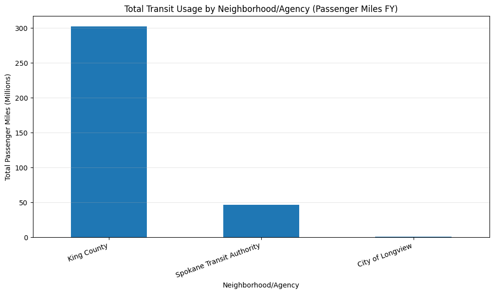

```
Saved chart to: output/total_usage_by_neighborhood_millions.png
```

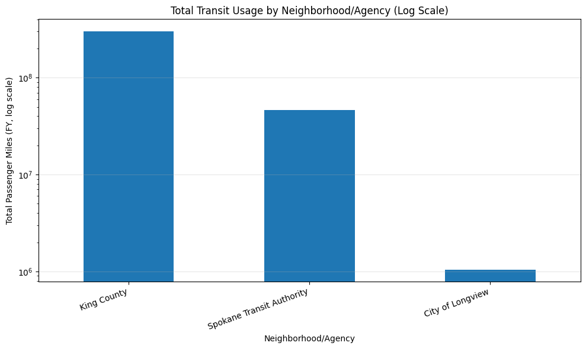

```
Saved chart to: output/total_usage_by_neighborhood_log.png
```

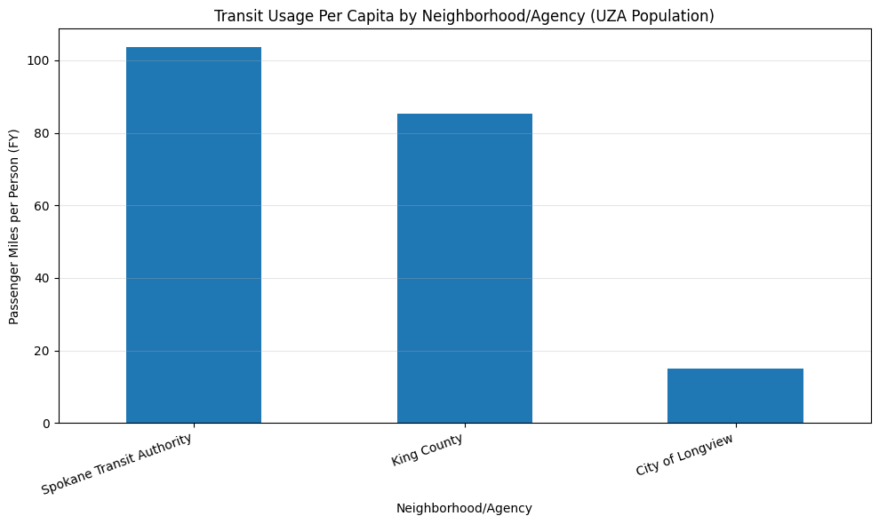

```
Saved chart to: output/usage_per_capita_by_neighborhood.png
```

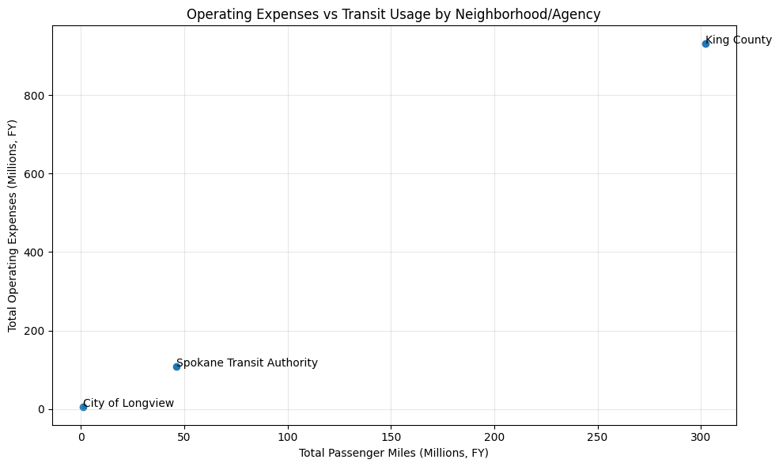

```
Saved chart to: output/cost_vs_usage_scatter_millions.png
```

```python
# --- Step 3: Create visuals that match what this dataset actually contains ---
# The FY fields in this file don't give a true month-by-month time series, so instead of forcing a "trend" line,
# I focus on stakeholder-friendly comparisons: total usage, per-capita usage, and cost efficiency.

from pathlib import Path  # defensive import (prevents NameError if cells run out of order)
from IPython.display import Image, display  # defensive import for HTML rendering

output_dir = Path("output")
output_dir.mkdir(exist_ok=True)

# 1) Total usage by neighborhood/agency (disparity view)
# This is the cleanest "headline" comparison for stakeholders.
totals = (
    filtered_df_plot.groupby(neigh_col)[ridership_col]
    .sum()
    .sort_values(ascending=False)
)

# For readability, I convert big totals into “millions” so stakeholders don’t have to interpret 1e8 style labels.
totals_m = totals / 1_000_000

plt.figure(figsize=(10, 6))
totals_m.plot(kind="bar")
plt.title("Total Transit Usage by Neighborhood/Agency (Passenger Miles FY)")
plt.xlabel("Neighborhood/Agency")
plt.ylabel("Total Passenger Miles (Millions)")
plt.grid(axis="y", alpha=0.3)  # light gridlines make comparisons easier to read
plt.xticks(rotation=20, ha="right")
plt.tight_layout()

output_file = output_dir / "total_usage_by_neighborhood_millions.png"
plt.savefig(output_file, bbox_inches="tight")
plt.close()
display(Image(filename=str(output_file)))
print(f"Saved chart to: {output_file}")

# OPTIONAL (but useful): log scale so smaller agencies are visible too
# This keeps the same story, but makes Spokane/Longview easier to see next to King County.
plt.figure(figsize=(10, 6))
totals.plot(kind="bar")
plt.title("Total Transit Usage by Neighborhood/Agency (Log Scale)")
plt.xlabel("Neighborhood/Agency")
plt.ylabel("Total Passenger Miles (FY, log scale)")
plt.yscale("log")
plt.grid(axis="y", alpha=0.3)
plt.xticks(rotation=20, ha="right")
plt.tight_layout()

log_output_file = output_dir / "total_usage_by_neighborhood_log.png"
plt.savefig(log_output_file, bbox_inches="tight")
plt.close()
display(Image(filename=str(log_output_file)))
print(f"Saved chart to: {log_output_file}")

# 2) Per-capita usage (equity/access view)
# This helps answer: are agencies serving their populations proportionally?
pop_candidates = ["UZA Population", "Service Area Population"]
pop_col = next((c for c in pop_candidates if c in filtered_df_plot.columns), None)

if pop_col is not None:
    # Some datasets store population as text; convert safely if needed.
    filtered_df_plot[pop_col] = pd.to_numeric(filtered_df_plot[pop_col], errors="coerce")

    # IMPORTANT: population is repeated across rows for the same agency, so I use max() as a stable single value.
    # I also protect against divide-by-zero and missing population values.
    pop_by_agency = filtered_df_plot.groupby(neigh_col)[pop_col].max()
    pop_by_agency = pop_by_agency.replace(0, pd.NA)

    per_capita = (totals / pop_by_agency).replace([float("inf"), -float("inf")], pd.NA).dropna()
    per_capita = per_capita.sort_values(ascending=False)

    plt.figure(figsize=(10, 6))
    per_capita.plot(kind="bar")
    plt.title(f"Transit Usage Per Capita by Neighborhood/Agency ({pop_col})")
    plt.xlabel("Neighborhood/Agency")
    plt.ylabel("Passenger Miles per Person (FY)")
    plt.grid(axis="y", alpha=0.3)
    plt.xticks(rotation=20, ha="right")
    plt.tight_layout()

    pc_output_file = output_dir / "usage_per_capita_by_neighborhood.png"
    plt.savefig(pc_output_file, bbox_inches="tight")
    plt.close()
    display(Image(filename=str(pc_output_file)))
    print(f"Saved chart to: {pc_output_file}")
else:
    print("No population column found for per-capita analysis (UZA Population / Service Area Population).")

# 3) Cost efficiency view (if available)
# This helps answer: does higher usage correlate with higher cost, and where are the outliers?
cost_col = "Operating Expenses FY" if "Operating Expenses FY" in filtered_df_plot.columns else None

if cost_col is not None:
    # These often come in as "$72,095,003.00" strings, so I strip symbols and commas before converting.
    if filtered_df_plot[cost_col].dtype == "object":
        filtered_df_plot[cost_col] = (
            filtered_df_plot[cost_col].astype(str)
            .str.replace("$", "", regex=False)
            .str.replace(",", "", regex=False)
            .str.strip()
        )
    filtered_df_plot[cost_col] = pd.to_numeric(filtered_df_plot[cost_col], errors="coerce")

if cost_col is not None and pd.api.types.is_numeric_dtype(filtered_df_plot[cost_col]):
    agg = filtered_df_plot.groupby(neigh_col)[[ridership_col, cost_col]].sum()

    # Same readability move here: put both axes in “millions” so the scatter isn’t dominated by huge numbers.
    usage_m = agg[ridership_col] / 1_000_000
    cost_m = agg[cost_col] / 1_000_000

    plt.figure(figsize=(10, 6))
    plt.scatter(usage_m, cost_m)

    # Labels help a lot here because there are only three agencies.
    for agency in agg.index:
        plt.annotate(agency, (usage_m.loc[agency], cost_m.loc[agency]))

    plt.title("Operating Expenses vs Transit Usage by Neighborhood/Agency")
    plt.xlabel("Total Passenger Miles (Millions, FY)")
    plt.ylabel("Total Operating Expenses (Millions, FY)")
    plt.grid(alpha=0.3)
    plt.tight_layout()

    ce_output_file = output_dir / "cost_vs_usage_scatter_millions.png"
    plt.savefig(ce_output_file, bbox_inches="tight")
    plt.close()
    display(Image(filename=str(ce_output_file)))
    print(f"Saved chart to: {ce_output_file}")
else:
    print("Operating Expenses FY not available as numeric for cost-efficiency scatter.")
```